# Mise à niveau R 2/3

26 février 2026

## Données

## Les variables

Créer un script R. Ecrire en haut à gauche.

```r
# Affectation
a <- 1
# ou encore
1 -> a
# mais éviter
a = 1
```

Exécuter (Ctrl+Entrée) : voir en bas à gauche. Environnement en haut à droite.

[figure not shown]

## R manipule des vecteurs

Plutôt que des nombres :

```r
x <- 1:5
2 * x
```

```
## [1]  2  4  6  8 10
```

```r
sqrt(x)
```

```
## [1] 1.000000 1.414214 1.732051 2.000000 2.236068
```

Introduction à R et au tidyverse, [Prise en main](https://juba.github.io/tidyverse/02-prise_en_main.html)

## Créer des vecteurs (1)

Des valeurs :

```r
(x <- 1)
```

```
## [1] 1
```

```r
(x <- c("pommes", "poires"))
```

```
## [1] "pommes" "poires"
```

```r
(x <- c(TRUE, FALSE))
```

```
## [1]  TRUE FALSE
```

## Créer des vecteurs (2)

Une séquence :

```r
(x <- 1:5)
```

```
## [1] 1 2 3 4 5
```

```r
(x <- seq(from = 1, to = 5, by = 1))
```

```
## [1] 1 2 3 4 5
```

## Créer des vecteurs (3)

Une répétition :

```r
(x <- rep(1, 5))
```

```
## [1] 1 1 1 1 1
```

```r
(x <- rep(1:2, each = 2))
```

```
## [1] 1 1 2 2
```

Utiliser systématiquement l’aide

```r
?rep
```

## Sélectionner des éléments (1)

Utiliser les crochets :

```r
x <- (1:10) * 10
x[3]
```

```
## [1] 30
```

```r
x[-5]
```

```
## [1]  10  20  30  40  60  70  80  90 100
```

Utiliser des vecteurs pour sélectionner :

```r
x[c(1, 3)]
```

```
## [1] 10 30
```

## Tester des éléments

Tirer des nombres dans une séquence, trouver lesquels sont pairs.

```r
x <- 1:100
# Échantillonnage
(y <- sample(x, 5))
```

```
## [1] 91 16 67 14 18
```

```r
(y %% 2 == 0)
```

```
## [1] FALSE  TRUE FALSE  TRUE  TRUE
```

## Sélectionner des éléments (2)

Utiliser les crochets :

```r
y[y %% 2 == 0]
```

```
## [1] 16 14 18
```

Les compter :

```r
sum(y %% 2 == 0)
```

```
## [1] 3
```

## Modes

Les vecteurs contiennent des données de même mode :

- numérique : `1:2`, `1L` (L pour un entier)
- imaginaire : `(1 + 1i) * (1 - 1i)` égale 2
- logique : `TRUE`
- caractère : `"Bonjour"`
- vide : `NULL`

## Matrices

Les matrices ont deux dimensions et contiennent des données de même mode

```r
(A <- matrix(1:9, nrow = 3))
```

```
##      [,1] [,2] [,3]
## [1,]    1    4    7
## [2,]    2    5    8
## [3,]    3    6    9
```

## Sélectionner dans une matrice

```r
A[1, 2]
```

```
## [1] 4
```

```r
A[, 3]
```

```
## [1] 7 8 9
```

## Tableaux

Extension des matrices à plus de deux dimensions

```r
A <- array(1:18, dim = c(3, 3, 2))
A
```

```
## , , 1
##
##      [,1] [,2] [,3]
## [1,]    1    4    7
## [2,]    2    5    8
## [3,]    3    6    9
##
## , , 2
##
##      [,1] [,2] [,3]
## [1,]   10   13   16
## [2,]   11   14   17
## [3,]   12   15   18
```

## Sélectionner dans un tableau

Comme dans une matrice :

```r
A[, , 2]
```

```
##      [,1] [,2] [,3]
## [1,]   10   13   16
## [2,]   11   14   17
## [3,]   12   15   18
```

## Listes

Eléments disparates :

```r
(L <- list(noms=c("X", "Y"), tailles = c(100, 120)))
```

```
## $noms
## [1] "X" "Y"
##
## $tailles
## [1] 100 120
```

## Sélectionner dans une liste

Double crochet ou nom :

```r
L[[2]]
```

```
## [1] 100 120
```

```r
L$noms
```

```
## [1] "X" "Y"
```

## Dataframe

Tableau dont chaque colonne est de mode unique :

```r
(df <- data.frame(nom = c("X", "Y"), taille = c(100, 120)))
```

```
##   nom taille
## 1   X    100
## 2   Y    120
```

## Sélectionner dans un dataframe (1)

Sélection comme dans une matrice…

```r
df[2, ]
```

```
##   nom taille
## 2   Y    120
```

… ou comme dans une liste

```r
df$taille
```

```
## [1] 100 120
```

## Sélectionner dans un dataframe (2)

Sélection de lignes en fonction de valeurs

```r
df[df$taille == 100, ]
```

```
##   nom taille
## 1   X    100
```

## Fonctions

## Définition

R est un langage fonctionnel.

```r
y <- cos(pi)
```

Une fonction produit une valeur à partir d’arguments.

## Effets de bord

Une fonction peut avoir des effets de bord :

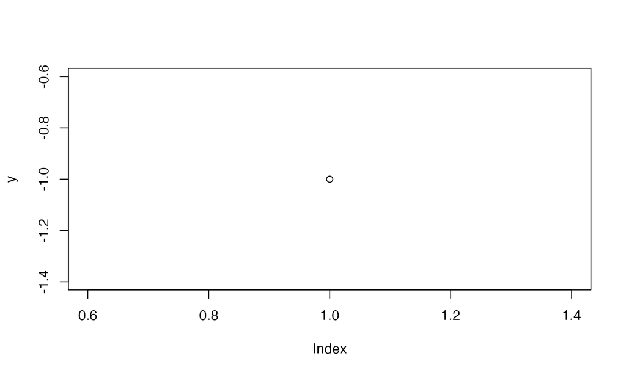

```r
x <- plot(y)
```

```r
x
```

`plot` n’est utilisé que pour ses effets de bord.

## Arguments

Appeler une fonction en nommant tous ses arguments…

```r
runif(n = 3, min = 0, max = 1)
```

```
## [1] 0.10293624 0.02248227 0.91641919
```

… ou en les passant dans l’ordre :

```r
runif(3, 0, 1)
```

```
## [1] 0.9096517 0.1370688 0.3397247
```

## Arguments nommés

Bonne pratique : nommer tous les arguments à partir du deuxième:

```r
runif(3, min = 0, max = 1)
```

```
## [1] 0.1005619 0.4669571 0.4286474
```

## Valeurs par défaut

Voir l’aide de la fonction : `?runif`

`min` et `max` ont des valeurs par défaut : 0 et 1.

```r
runif(3)
```

```
## [1] 0.53216272 0.09179518 0.02105684
```

## Créer

Syntaxe:

```r
puissance <- function(x, r = 1) {
  return(x^r)
}
puissance(1:3, r = 2)
```

```
## [1] 1 4 9
```

Penser vecteur. `r` est recyclé.

```r
puissance(1:3, r = 3:1)
```

```
## [1] 1 4 3
```

## Fonctions opérateurs (*infix functions*)

Les opérateurs de R sont en fait des fonctions:

```r
identical(2 + 2, `+`(2, 2))
```

```
## [1] TRUE
```

Les opérateurs définis par l’utilisateur sont obligatoirement entre % :

```r
`%+%` <- function(a, b) paste(a, b)
"Nouvelle" %+% "chaîne"
```

```
## [1] "Nouvelle chaîne"
```

[Référence](http://adv-r.had.co.nz/Functions.html#special-calls)

## Argument …

Les `...` sont des arguments libres à passer à une autre fonction :

```r
f <- function(x) x
g <- function(y, ...) f(...)
g("Rien", x = "Argument x passé à f par g")
```

```
## [1] "Argument x passé à f par g"
```

Mais il faut que tout argument soit reconnu par une fonction :

```r
tryCatch(g("Rien", z = 2), error= function(e) print(e))
```

```
## <simpleError in f(...): unused argument (z = 2)>
```

## Structures de contrôle

## Si / Sinon

```r
est_pair <- function(x) {
  if (x %% 2 == 0) {
    return(TRUE)
  } else {
    return(FALSE)
  }
}
est_pair(3)
```

```
## [1] FALSE
```

Fonction non vectorielle. Utiliser plutôt :

```r
((1:3) %% 2) == 0
```

```
## [1] FALSE  TRUE FALSE
```

## Boucles

```r
for (i in 1:3) {
  print(sqrt(i))
}
```

```
## [1] 1
## [1] 1.414214
## [1] 1.732051
```

Seulement si la fonction utilisée n’est pas vectorielle.

```r
sqrt(1:3)
```

```
## [1] 1.000000 1.414214 1.732051
```

## Graphiques de base

## plot

Graphiques simples :

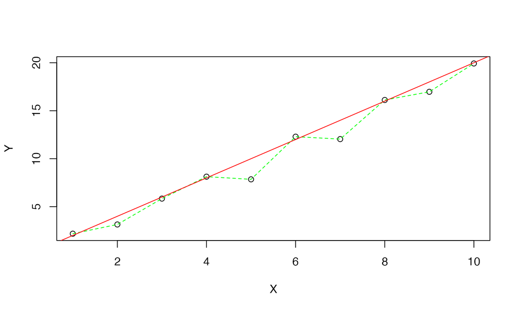

```r
X <- 1:10
Y <- 2 * X + rnorm(n = length(X))
plot(x = X, y = Y)
lines(x = X, y = Y, col = "green", lty = 2)
abline(a = 0, b = 2, col = "red")
```

## Classes (1)

Les objets appartiennent à des classes.

```r
Ns <- rlnorm(100)
class(Ns)
```

```
## [1] "numeric"
```

`plot` est une méthode, déclinée par classe.

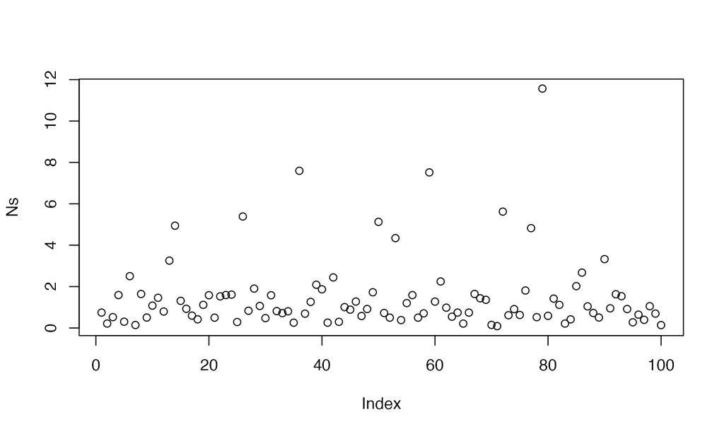

```r
plot(Ns) # plot.numeric()
```

## Classes (2)

```r
library("entropart")
Ns <- as.AbdVector(Ns)
class(Ns)
```

```
## [1] "AbdVector"           "SpeciesDistribution"
## [3] "integer"
```

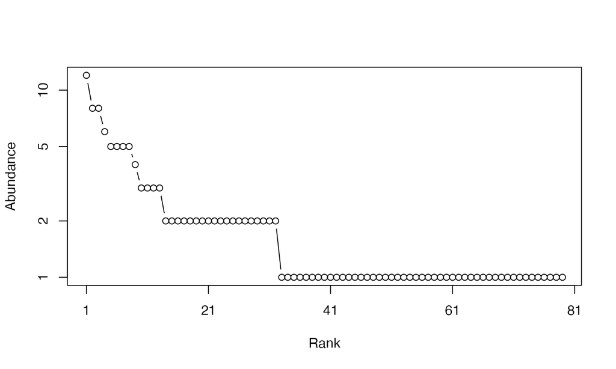

```r
plot(Ns) # plot.SpeciesDistribution
```